```python
import numpy as np
import matplotlib.pyplot as plt
from scipy.integrate import solve_ivp
from scipy.integrate import quad
```

# Part 1

```
Analytic fall time: 28.5569 s
Numerical fall time: 28.5569 s
```

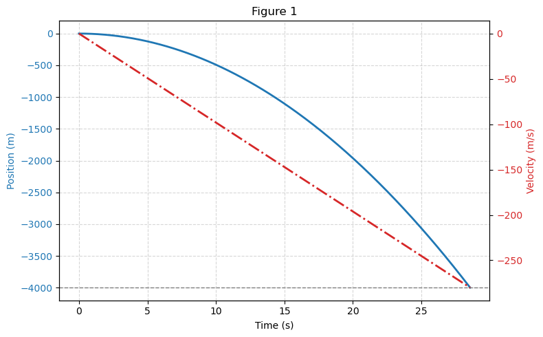

```python
g0 = 9.81
H = 4000.0
g0 = 9.81
Re = 6378.1e3
Omega = 7.272e-5

t_analytic = np.sqrt(2*H/g0)

def freefall_down_ode(t, y):
    return [y[1], -g0]

def event_bottom_down(t, y):
    return y[0] + H
event_bottom_down.terminal = True
event_bottom_down.direction = -1

sol_down = solve_ivp(freefall_down_ode, [0, 100], [0, 0], events=event_bottom_down, max_step=0.1)

t_numeric = sol_down.t_events[0][0]

print(f"Analytic fall time: {t_analytic:.4f} s")
print(f"Numerical fall time: {t_numeric:.4f} s")

fig, ax1 = plt.subplots(figsize=(8,5))

color_pos = 'tab:blue'
ax1.set_xlabel('Time (s)')
ax1.set_ylabel('Position (m)', color=color_pos)
ax1.plot(sol_down.t, sol_down.y[0], color=color_pos, linewidth=2)
ax1.tick_params(axis='y', labelcolor=color_pos)
ax1.axhline(-H, color='gray', linestyle='--', linewidth=1)
ax1.grid(True, linestyle='--', alpha=0.5)

ax2 = ax1.twinx()
color_vel = 'tab:red'
ax2.set_ylabel('Velocity (m/s)', color=color_vel)
ax2.plot(sol_down.t, sol_down.y[1], color=color_vel, linewidth=2, linestyle='-.')
ax2.tick_params(axis='y', labelcolor=color_vel)

plt.title('Figure 1')
fig.tight_layout()
plt.show()
```

The numerical fall time (28.5569 s) exactly matches the analytic calculation (28.5569 s), indicating the numerical solution's high accuracy under these ideal conditions (constant g, no drag). There would probably be differences that only emerge only from numerical rounding or step-size choices, neither significant here.

# Part 2

```
fall time no drag = 28.558 s
fall time with drag = 83.545 s
```

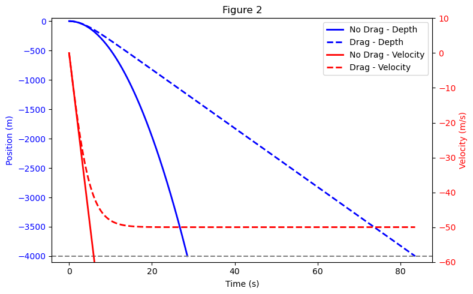

```python
v_terminal = 50.0
alpha = g0 / (v_terminal**2)

def var_g_no_drag_flip(t, Y):
    s, v = Y
    r = Re + s
    g_var = g0 * (r / Re)
    return [v, -g_var]

def var_g_with_drag_flip(t, Y):
    s, v = Y
    r = Re + s
    g_var = g0 * (r / Re)
    return [v, -g_var + alpha*(v**2)]

def event_bottom_flip(t, Y):
    return Y[0] + H
event_bottom_flip.terminal = True
event_bottom_flip.direction = -1

Y0 = [0.0, 0.0]

sol_nodrag_flip = solve_ivp(var_g_no_drag_flip, [0, 200], Y0, events=event_bottom_flip, max_step=0.1)
sol_drag_flip = solve_ivp(var_g_with_drag_flip, [0, 300], Y0, events=event_bottom_flip, max_step=0.1)

t_hit_nodrag_flip = sol_nodrag_flip.t_events[0][0]
t_hit_drag_flip = sol_drag_flip.t_events[0][0]

print(f"fall time no drag = {t_hit_nodrag_flip:.3f} s")
print(f"fall time with drag = {t_hit_drag_flip:.3f} s")

fig, ax1 = plt.subplots(figsize=(8,5))
ax1.set_xlabel('Time (s)')
ax1.set_ylabel('Position (m)', color='blue')
line1, = ax1.plot(sol_nodrag_flip.t, sol_nodrag_flip.y[0], 'b-', linewidth=2, label='No Drag - Depth')
line2, = ax1.plot(sol_drag_flip.t, sol_drag_flip.y[0], 'b--', linewidth=2, label='Drag - Depth')
ax1.tick_params(axis='y', labelcolor='blue')
ax1.axhline(-H, color='gray', linestyle='--', label='Bottom (-H)')
ax1.set_ylim([-H-100, 50])
ax1.set_title('Figure 2')

ax2 = ax1.twinx()
ax2.set_ylabel('Velocity (m/s)', color='red')
line3, = ax2.plot(sol_nodrag_flip.t, sol_nodrag_flip.y[1], 'r-', linewidth=2, label='No Drag - Velocity')
line4, = ax2.plot(sol_drag_flip.t, sol_drag_flip.y[1], 'r--', linewidth=2, label='Drag - Velocity')
ax2.tick_params(axis='y', labelcolor='red')
ax2.set_ylim([-60, 10])

lines = [line1, line2, line3, line4]
labels = [line.get_label() for line in lines]
ax1.legend(lines, labels, loc='best')

fig.tight_layout()
plt.show()
```

Adding a height-dependent g slightly increases the fall time compared to using constant gravity. This is because as the object falls deeper, its distance from Earth’s center decreases, which reduces the local gravitational acceleration according to

*g(r) = g0 * (g/R0)*

This means the test mass experiences slightly weaker acceleration the further it falls, so it takes longer to reach the bottom. THat is why the fall time increased from 28.557 s (constant g) to 28.558 s (variable g), which is small yet a measurable difference.

# Part 3

```
No drag, mass hits wall at t = 21.9068298656 s, depth = -2353.9526089629 m.
With drag, mass hits wall at t = 75.4566054159 s, depth = -3596.1859350741 m.
```

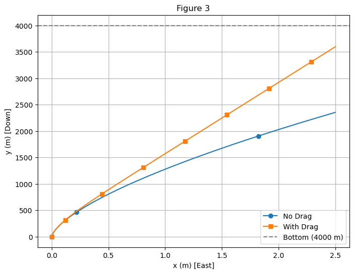

```python
shaft_halfwidth = 2.5

v_terminal = 50.0
alpha = g0 / (v_terminal**2)

def coriolis_no_drag(t, Y):
    x, vx, y, vy = Y
    ax = 2 * Omega * vy
    ay = g0 - 2 * Omega * vx
    return [vx, ax, vy, ay]

def coriolis_with_drag(t, Y):
    x, vx, y, vy = Y
    ax_c = 2 * Omega * vy
    ay_c = g0 - 2 * Omega * vx
    speed = np.sqrt(vx**2 + vy**2)
    if speed < 1e-12:
        ax_d, ay_d = 0.0, 0.0
    else:
        ax_d = -alpha * speed * vx
        ay_d = -alpha * speed * vy
    return [vx, ax_c + ax_d, vy, ay_c + ay_d]

def event_bottom(t, Y):
    return Y[2] - H
event_bottom.terminal = True
event_bottom.direction = 1

def event_wall(t, Y):
    return shaft_halfwidth - abs(Y[0])
event_wall.terminal = True
event_wall.direction = -1

Y0 = [0.0, 0.0, 0.0, 0.0]

sol_no_drag = solve_ivp(coriolis_no_drag, [0, 2000], Y0, events=[event_bottom, event_wall], max_step=0.1)

sol_drag = solve_ivp(coriolis_with_drag, [0, 3000], Y0, events=[event_bottom, event_wall], max_step=0.1)

times_bottom = sol_no_drag.t_events[0]
times_wall = sol_no_drag.t_events[1]
if len(times_wall) > 0:
    wall_depth_no_drag = sol_no_drag.y_events[1][0][2]
    print(f"No drag, mass hits wall at t = {times_wall[0]:.10f} s, depth = {-wall_depth_no_drag:.10f} m.")
elif len(times_bottom) > 0:
    print(f"No drag, mass reaches bottom at t = {times_bottom[0]:.10f} s.")
else:
    print("No drag scenario: No event detected.")

times_bottom_d = sol_drag.t_events[0]
times_wall_d = sol_drag.t_events[1]
if len(times_wall_d) > 0:
    wall_depth_drag = sol_drag.y_events[1][0][2]
    print(f"With drag, mass hits wall at t = {times_wall_d[0]:.10f} s, depth = {-wall_depth_drag:.10f} m.")
elif len(times_bottom_d) > 0:
    print(f"With drag, mass reaches bottom at t = {times_bottom_d[0]:.10f} s.")
else:
    print("Drag scenario: No event detected.")

plt.figure(figsize=(8,6))
line1, = plt.plot(sol_no_drag.y[0], sol_no_drag.y[2], '-o', markevery=100, label='No Drag')
line2, = plt.plot(sol_drag.y[0], sol_drag.y[2], '-s', markevery=100, label='With Drag')
plt.axhline(H, color='gray', linestyle='--', label='Bottom (4000 m)')
plt.xlabel('x (m) [East]')
plt.ylabel('y (m) [Down]')
plt.title('Figure 3')
plt.legend(loc='best')
plt.grid(True)
plt.show()
```

For no drag, the mass hits the wall at x = +/-2.5 m before reaching y=4000. This is probably because the coriolis force quickly deflects the mass sideways in the narrow shaft.

With drag on however, the mass still hits the wall, but at a later time (t=75.457 s). Drag slows both vertical and horizontal velocity, so it drifts sideways more slowly but still contacts the wall. Drag does make a difference by delaying the collission with the shaft wall, but cannot entirely stop it. The test mass still fails to reach the bottom in the 5 meter shaft.

# Part 4

```
Reached Earth's center at t = 1266.575 s, speed = -7910.067 m/s
Never reached opposite side in given timeframe.
```

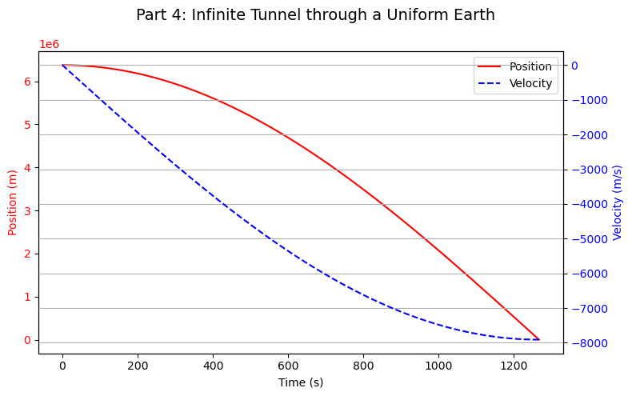

```
approx orbital period near Earth's surface: 5069.37 s
```

```python
ge = 6.6743e-11
me = 5.972e24
R_EARTH = 6378.1e3
G0 = 9.81

def orbital_period(mass, radius):
    return 2 * np.pi * radius / np.sqrt(ge * mass / radius)

def tunnel_ode_uniform(t, state):
    y, vy = state
    r = R_EARTH + y
    grav_local = G0 * (r / R_EARTH)
    dydt = vy
    dvdt = -grav_local
    return [dydt, dvdt]

def event_center(t, state):
    return state[0] + R_EARTH
event_center.terminal = True
event_center.direction = 0

def event_opposite_side(t, state):
    return state[0] + 2*R_EARTH
event_opposite_side.terminal = True
event_opposite_side.direction = 0

def run_part4_infinite_tunnel():
    t0, tmax = 0, 3000
    t_span = (t0, tmax)

    y_init = 0.0
    vy_init = 0.0
    init_state = [y_init, vy_init]

    sol = solve_ivp(
        tunnel_ode_uniform,
        t_span,
        init_state,
        max_step=0.5,
        dense_output=True,
        events=[event_center, event_opposite_side],
        rtol=1e-9
    )

    if len(sol.t_events[0]) > 0:
        t_center = sol.t_events[0][0]
        y_center, v_center = sol.sol(t_center)
        print(f"Reached Earth's center at t = {t_center:.3f} s, speed = {v_center:.3f} m/s")
    else:
        print("Center not reached in given timeframe.")

    if len(sol.t_events[1]) > 0:
        t_other_side = sol.t_events[1][0]
        y_otherside, v_otherside = sol.sol(t_other_side)
        print(f"Reached opposite side at t = {t_other_side:.3f} s, speed = {v_otherside:.3f} m/s")
    else:
        print("Never reached opposite side in given timeframe.")

    t_vals = sol.t
    y_vals = sol.y[0]
    v_vals = sol.y[1]

    fig, ax1 = plt.subplots(figsize=(8,5))
    ax1.set_xlabel("Time (s)")
    ax1.set_ylabel("Position (m)", color="red")
    ax1.plot(t_vals, y_vals + R_EARTH, color="red", label="Position")
    ax1.tick_params(axis="y", labelcolor="red")

    ax2 = ax1.twinx()
    ax2.set_ylabel("Velocity (m/s)", color="blue")
    ax2.plot(t_vals, v_vals, "--", color="blue", label="Velocity")
    ax2.tick_params(axis="y", labelcolor="blue")

    fig.suptitle("Part 4: Infinite Tunnel through a Uniform Earth", fontsize=14)

    lines1, labels1 = ax1.get_legend_handles_labels()
    lines2, labels2 = ax2.get_legend_handles_labels()
    ax1.legend(lines1 + lines2, labels1 + labels2, loc="best")

    plt.grid(True)
    plt.tight_layout()
    plt.show()

    T_est = orbital_period(me, R_EARTH)
    print(f"approx orbital period near Earth's surface: {T_est:.2f} s")

run_part4_infinite_tunnel()
```

The object takes 1266.6 x 2 so 2533s to get to the opposite side.

The orbital period is around 5069.37 s which is rougly twice the single crossing time so half the period covers a single crossing, which makes sense.

# Part 5

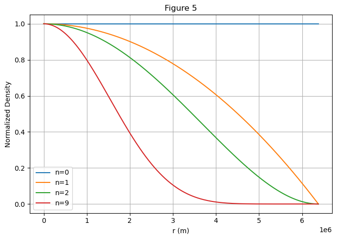

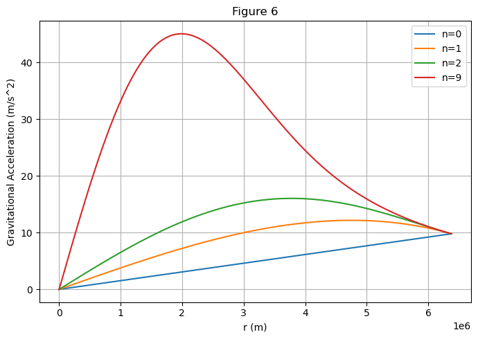

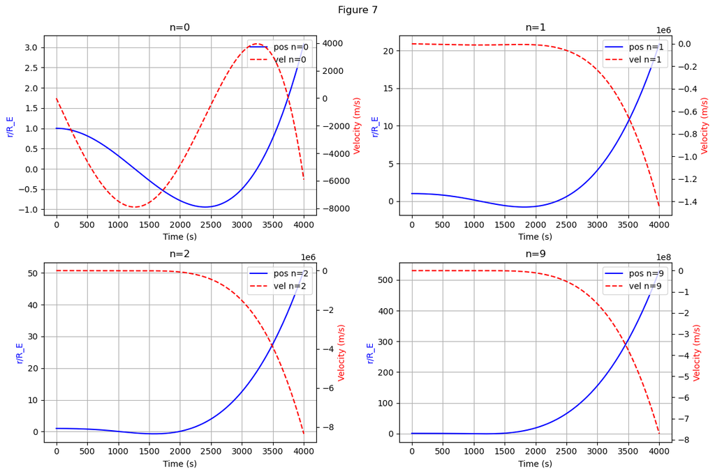

```
0 1267.3427999189466
1 1096.5129862796614
2 1035.075647186906
9 943.7775313471495
```

```python
import numpy as np
import matplotlib.pyplot as plt
from scipy.integrate import quad, solve_ivp

Gval = 6.6743e-11
Mearth = 5.972e24
Rearth = 6378.1e3
nList = [0,1,2,9]
rArr = np.linspace(0, Rearth, 300)

def densityNorm(r, n):
    return (1 - (r**2 / Rearth**2))**n if r<=Rearth else 0.0

def massUnscaled(n):
    f = lambda x: 4*np.pi*x**2*(1 - (x**2/Rearth**2))**n
    val, _ = quad(f, 0, Rearth)
    return val

def enclosedMass(r, rho0, n):
    g = lambda x: 4*np.pi*x**2*rho0*(1 - (x**2/Rearth**2))**n
    val, _ = quad(g, 0, r)
    return val

# Figure 5
plt.figure(figsize=(7,5))
for n in nList:
    vals = [densityNorm(rr, n) for rr in rArr]
    plt.plot(rArr, vals, label=f"n={n}")
plt.title("Figure 5")
plt.xlabel("r (m)")
plt.ylabel("Normalized Density")
plt.legend()
plt.grid()
plt.tight_layout()
plt.show()

# Figure 6
plt.figure(figsize=(7,5))
for n in nList:
    mu = massUnscaled(n)
    rho0 = Mearth / mu
    forceVals = []
    for rr in rArr:
        if rr == 0:
            forceVals.append(0)
        else:
            mEnc = enclosedMass(rr, rho0, n)
            forceVals.append(Gval*mEnc/(rr**2))
    plt.plot(rArr, forceVals, label=f"n={n}")
plt.title("Figure 6")
plt.xlabel("r (m)")
plt.ylabel("Gravitational Acceleration (m/s^2)")
plt.legend()
plt.grid()
plt.tight_layout()
plt.show()

# Figure 7
def dens(r,n0,exp0):
    return n0*(1 - (r**2 / Rearth**2))**exp0 if r<=Rearth else 0.0

def mEnc(r,n0,exp0):
    h = lambda x: 4*np.pi*x**2*dens(x,n0,exp0)
    val,_ = quad(h, 0, r)
    return val

def ode(t, s, n0, exp0):
    rv, vv = s
    if abs(rv)<1e-9:
        return [vv, 0]
    mm = mEnc(abs(rv),n0,exp0)
    return [vv, -np.sign(rv)*Gval*mm/(abs(rv)**2)]

def eventCore(t, s, *args):
    return s[0]
eventCore.terminal=True
eventCore.direction=-1

timeRange=(0,4000)
r0=[Rearth,0]
tt=np.linspace(timeRange[0],timeRange[1],300)
denseT=np.linspace(timeRange[0],timeRange[1],800)

fig, axs=plt.subplots(2,2,figsize=(12,8))
axs=axs.flatten()
crossT={}
for i,n in enumerate(nList):
    ax1=axs[i]
    ax2=ax1.twinx()
    mu2=massUnscaled(n)
    scaleVal=Mearth/mu2
    sol=solve_ivp(ode,timeRange,r0,t_eval=tt,dense_output=True,
                  args=(scaleVal,n),events=eventCore,max_step=1)
    if sol.t_events[0].size>0:
        crossT[n]=sol.t_events[0][0]
    else:
        crossT[n]=None
    dSol=sol.sol(denseT)
    pr=dSol[0]/Rearth
    vv=dSol[1]
    ax1.plot(denseT,pr,label=f"pos n={n}",color="blue")
    ax2.plot(denseT,vv,"--",label=f"vel n={n}",color="red")
    ax1.set_title(f"n={n}")
    ax1.set_xlabel("Time (s)")
    ax1.set_ylabel("r/R_E",color="blue")
    ax2.set_ylabel("Velocity (m/s)",color="red")
    lines1,labels1=ax1.get_legend_handles_labels()
    lines2,labels2=ax2.get_legend_handles_labels()
    ax1.legend(lines1+lines2,labels1+labels2,loc="upper right")
    ax1.grid()
plt.suptitle("Figure 7")
plt.tight_layout()
plt.show()

for n in nList:
    print(n,crossT[n])
```

# Part 6

```
Time to reach Moon center (uniform density): 1624.46 s
Approx. Earth density: 5494.9 kg/m³
Approx. Moon density:  3344.5 kg/m³
Density ratio (Moon/Earth): 0.609
```

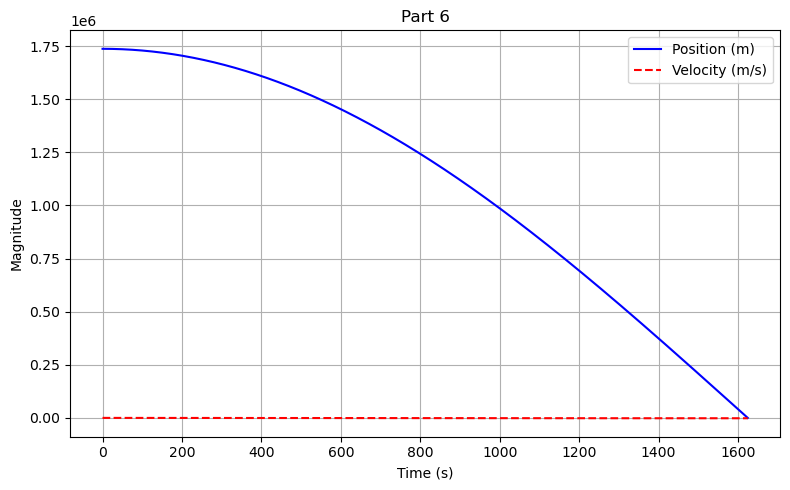

```
scaled density factor=0.5, center time=2297.04 s
scaled density factor=1.0, center time=1624.25 s
scaled density factor=2.0, center time=1148.49 s
```

```python
import numpy as np
import matplotlib.pyplot as plt
from scipy.integrate import solve_ivp

G_const    = 6.6743e-11
R_earth    = 6.3781e6
M_earth    = 5.972e24
R_moon     = 1.737e6
M_moon     = 7.342e22

def moon_ode_uniform(t, y):
    r, v = y
    a = - (G_const * M_moon / (R_moon**3)) * r
    return [v, a]

def event_moon_center(t, y):
    return y[0]
event_moon_center.terminal = True
event_moon_center.direction = -1

def solve_moon_uniform():
    y0 = [R_moon, 0.0]
    t_span = [0, 5000]
    sol = solve_ivp(
        moon_ode_uniform,
        t_span,
        y0,
        events=event_moon_center,
        dense_output=True,
        max_step=1
    )
    return sol

solution_moon = solve_moon_uniform()
center_time_moon = None
if len(solution_moon.t_events[0]) > 0:
    center_time_moon = solution_moon.t_events[0][0]
    print(f"Time to reach Moon center (uniform density): {center_time_moon:.2f} s")
else:
    print("did not reach center within time limit")

rho_earth = M_earth / ((4/3)*np.pi*(R_earth**3))
rho_moon  = M_moon  / ((4/3)*np.pi*(R_moon**3))
print(f"Approx. Earth density: {rho_earth:.1f} kg/m³")
print(f"Approx. Moon density:  {rho_moon:.1f} kg/m³")
print(f"Density ratio (Moon/Earth): {rho_moon / rho_earth:.3f}")

t_vals = solution_moon.t
r_vals = solution_moon.y[0]
v_vals = solution_moon.y[1]

plt.figure(figsize=(8,5))
plt.plot(t_vals, r_vals, label="Position (m)", color='blue')
plt.plot(t_vals, v_vals, label="Velocity (m/s)", color='red', linestyle='--')
plt.xlabel("Time (s)")
plt.ylabel("Magnitude")
plt.title("Part 6")
plt.grid(True)
plt.legend()
plt.tight_layout()
plt.show()

def scaled_moon_ode(t, y, scale_mass):
    r, v = y
    a = - (G_const * scale_mass / (R_moon**3)) * r
    return [v, a]

dens_scales = [0.5, 1.0, 2.0]
for factor in dens_scales:
    def event_center_scaled(t, y):
        return y[0]
    event_center_scaled.terminal = True
    event_center_scaled.direction = -1
    sol_scaled = solve_ivp(
        lambda t, s: scaled_moon_ode(t, s, M_moon*factor),
        [0, 5000],
        [R_moon, 0],
        events=event_center_scaled,
        dense_output=True
    )
    if len(sol_scaled.t_events[0])>0:
        print(f"scaled density factor={factor}, center time={sol_scaled.t_events[0][0]:.2f} s")
    else:
        print(f"Scaled density factor={factor}, did not reach center.")
```

The time (T) for an object to cross a uniformly dense planet follows simple harmonic motion. That means the crossing time is inversely proportional to the square root of the planet's density (rho):

T ∝ 1 / √(ρ)

- Higher density → Stronger gravitational pull → Shorter crossing time
- Lower density → Weaker gravitational pull → Longer crossing time